# MOMS_PI_Calibration

Jacob T. Nearing

8/6/2021

# Estimate Bias from Mock communities

```r
dr <- system.file("extdata", package = "metacal")
list.files(dr)
```

```
## [1] "brooks2015-actual.csv"      "brooks2015-observed.csv"
## [3] "brooks2015-sample-data.csv"
```

```
#> [1] "brooks2015-actual.csv"      "brooks2015-observed.csv"
#> [3] "brooks2015-sample-data.csv"
```

```r
actual <- file.path(dr, "brooks2015-actual.csv") %>%
  read.csv(row.names = "Sample") %>%
  as("matrix")

observed <- file.path(dr, "brooks2015-observed.csv") %>%
  read.csv(row.names = "Sample") %>%
  subset(select = - Other) %>%
  as("matrix")

sam <- file.path(dr, "brooks2015-sample-data.csv") %>% read.csv()

# Estimate bias with bootstrapping for error estimation
mc_fit <- estimate_bias(observed, actual, margin = 1, boot = TRUE)
```

```
## Zeroing 175 values in `observed`
```

```r
summary(mc_fit)
```

```
## Summary of a metacal bias fit.
##
## Estimated relative efficiencies:
## # A tibble: 7 × 4
##   taxon                    estimate gm_mean gm_se
##   <chr>                       <dbl>   <dbl> <dbl>
## 1 Atopobium_vaginae           0.285   0.285  1.04
## 2 Gardnerella_vaginalis       0.160   0.160  1.04
## 3 Lactobacillus_crispatus     2.29    2.29   1.03
## 4 Lactobacillus_iners         4.68    4.68   1.02
## 5 Prevotella_bivia            1.79    1.79   1.04
## 6 Sneathia_amnii              4.59    4.59   1.04
## 7 Streptococcus_agalactiae    0.250   0.250  1.03
##
## Geometric standard error estimated from 1000 bootstrap replicates.
```

```r
#Load in MOMS_PI data
MOMS_PI_table <- read.csv("~/projects/MOMSPI/STIRRUPs_Profiles/abundance-matrix.csv", check.names = F, row.names=1)

#two crispatus so we need to combined them
grep("crispatus", colnames(MOMS_PI_table))
```

```
## [1] 205 206
```

```r
crisp_reads <- MOMS_PI_table[,205] + MOMS_PI_table[,206]
MOMS_PI_table <- MOMS_PI_table[,-c(205,206)]
MOMS_PI_table$Lactobacillus_crispatus <- crisp_reads

MOMS_meta <- read.csv("~/projects/MOMSPI/sample-data.csv")
rownames(MOMS_meta) <- MOMS_meta$sample_name

MOMS_meta <- MOMS_meta[rownames(MOMS_PI_table),]
```

Looks just like what is reported in the 2019 eLife paper.

# Functions for MOMS_PI_exploration

```r
Visit_Fold_changes <- function(x){

  changes_compute <- ncol(x) - 1

  FC_change <- matrix(-1,nrow=nrow(x), ncol=changes_compute)

  ## this is a really bad way of doing it but will do for now..
  #go through rows
  for(i in 1:nrow(x)){
    #go through first col
    for(j in 1:(ncol(x) - 1)){
      #go through cols

      FC_val <- x[i,j+1]/x[i,j]
      FC_change[i,j] <- FC_val


    }
  }
  rownames(FC_change) <- rownames(x)
  return(FC_change)
}

## function takes in a sample name and produces both a stacked barchart of observed vs calibrated and line plots showing the changes over time of each
get_calibrated_plots <- function(observed_vals, bias_estimate, non_esti_action="remove", meta){


  estimate_taxa <- names(bias_estimate$estimate)
  coef_bias <- coef(bias_estimate)


  if(non_esti_action=="remove"){

    #remove taxa that are not estiamted
    subset_ob <- observed_vals[,which(colnames(observed_vals) %in% estimate_taxa)]

    subset_ob_RA <- sweep(subset_ob, 1, rowSums(subset_ob), "/")

    cali_tab <- calibrate(subset_ob_RA, coef_bias, margin=1)

    melt_subset_ob <- reshape2::melt(subset_ob_RA)
    melted_cali_tab <- reshape2::melt(cali_tab)

    melt_subset_ob$Type <- "Observed"
    melted_cali_tab$Type <- "Calibrated"

    long_data <- rbind(melt_subset_ob, melted_cali_tab)

    long_data$Visit <- meta$host_visit_number[match(long_data$Var1, meta$sample_name)]
    long_data$Visit <- factor(long_data$Visit, levels=c(1:1000))
  }

  plot1 <- ggplot(long_data, aes(x=Visit, y=value, fill=Var2)) + geom_bar(stat="identity") +
    facet_grid(~ Type) +
    theme(axis.text.x = element_text(angle=75, vjust = 0.55)) + scale_fill_discrete(name="Taxa")

  plot2 <- ggplot(long_data, aes(x=Visit, y=value, color=Type, group=Type)) + geom_line() + facet_grid(rows=vars(Var2)) +
  theme_bw() + ylab("Relative Abundance")


  ## calculate log_fold_change for each taxa

  Observed_temp <- long_data[which(long_data$Type=="Observed"),]
  Observed_agg <- dcast(Observed_temp, formula = Var2 ~ Var1 + Visit)
  rownames(Observed_agg) <- Observed_agg[,1]
  Observed_agg <- Observed_agg[,-1]
  Observed_FC <- Visit_Fold_changes(Observed_agg)


  Calibrated_temp <- long_data[which(long_data$Type=="Calibrated"),]
  Calibrated_agg <- dcast(Calibrated_temp, formula = Var2 ~ Var1 + Visit)
  rownames(Calibrated_agg) <- Calibrated_agg[,1]
  Calibrated_agg <- Calibrated_agg[,-1]
  Calibrated_FC <- Visit_Fold_changes(Calibrated_agg)

  return(list(plot1,plot2,Observed_FC, Calibrated_FC))


}
```

Two functions First one is simply to caluclate the fold change of taxa between subsequent visits The second takes in a matrix that is a subset of the MOMS PI taxa abundance table that only contains a single patient/host of interest. It produces a stacked barchart comparing observed vs calibrated Line plots showing the differene in taxon relative abundance changes over time for calibarated vs observed Then two dataframe that contain the fold changes for the calibrate and observed.

# Data Exploration

```r
melted_MOMS_PI_table <- reshape2::melt(as.matrix(MOMS_PI_table))
melted_MOMS_PI_table$host_id <- MOMS_meta$host_subject_id[match(melted_MOMS_PI_table$Var1, MOMS_meta$sample_name)]

#calculate Cov of each taxa for each patient
CoV_of_Taxa <- aggregate(melted_MOMS_PI_table$value, by=list(melted_MOMS_PI_table$host_id, melted_MOMS_PI_table$Var2),
                        FUN=function(x) sd(x)/mean(x))
```

## Examine subject with the most samples

Subject EP154266

```r
which.max(table(MOMS_meta$host_subject_id))
```

```
## EP154266
##       85
```

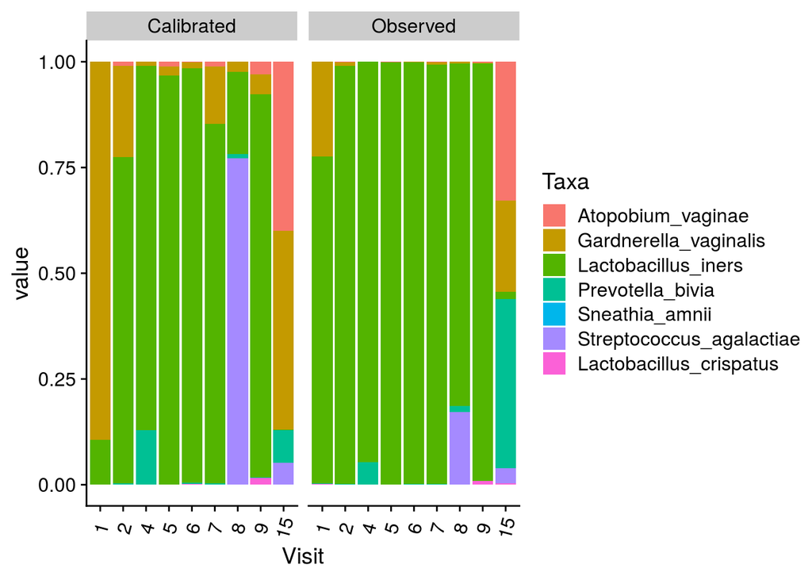

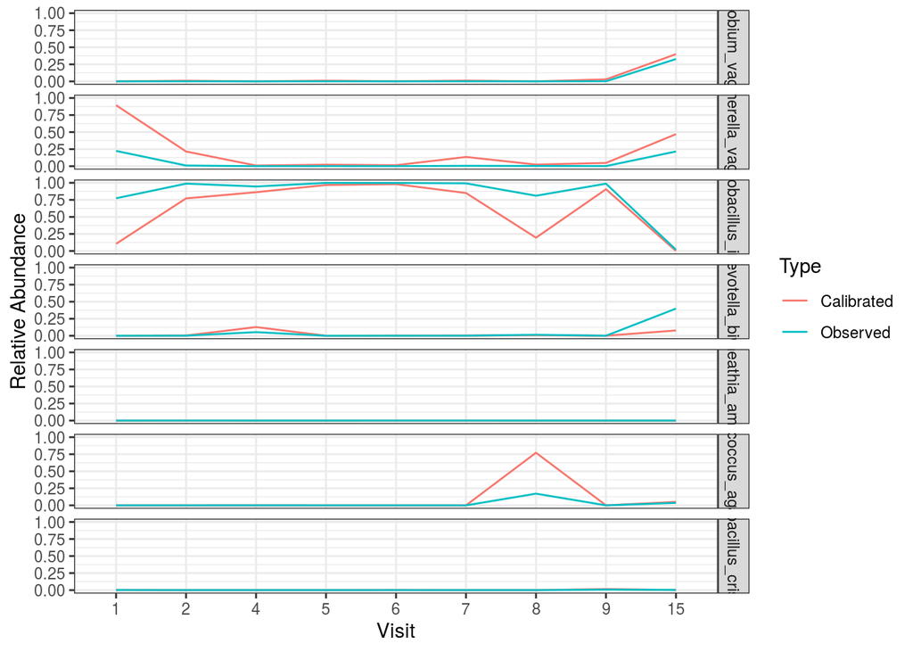

```
##
## [[3]]
##                                 [,1]         [,2]        [,3]        [,4]
## Atopobium_vaginae                Inf  0.002275103  0.00000000         Inf
## Gardnerella_vaginalis      0.9645548  0.043529948  0.03726855 2.190136771
## Lactobacillus_iners        0.0235883 54.156363912  0.95776610 1.055463363
## Prevotella_bivia         552.5221470  0.004185161 31.95599137 0.001487303
## Sneathia_amnii                   NaN          Inf  0.23667120 0.000000000
## Streptococcus_agalactiae         Inf  0.000000000         Inf 0.000000000
## Lactobacillus_crispatus    1.3000521  0.040424851  1.53836282 0.000000000
##                                [,5]        [,6]        [,7]         [,8]
## Atopobium_vaginae         0.1249748  9.77928830  0.07059661 3.477002e+01
## Gardnerella_vaginalis     0.6464214 10.83192002  0.62673852 5.223539e-01
## Lactobacillus_iners       0.9990001  0.99458366  0.81688767 1.218239e+00
## Prevotella_bivia         11.1088722  1.56621414 10.70313418 3.508733e-02
## Sneathia_amnii                  Inf  1.05571862  0.00000000          NaN
## Streptococcus_agalactiae        NaN         NaN         Inf 1.314636e-04
## Lactobacillus_crispatus         Inf  0.04527448  0.84715927 2.955452e+02
##
## [[4]]
##                                  [,1]         [,2]        [,3]        [,4]
## Atopobium_vaginae                 Inf   0.02392460  0.00000000         Inf
## Gardnerella_vaginalis      0.52594062   0.45775362  0.04349131 2.328555021
## Lactobacillus_iners        0.01286194 569.49922660  1.11768503 1.122169422
## Prevotella_bivia         301.27250796   0.04401045 37.29170772 0.001581302
## Sneathia_amnii                    NaN          Inf  0.27618838 0.000000000
## Streptococcus_agalactiae          Inf   0.00000000         Inf 0.000000000
## Lactobacillus_crispatus    0.70887649   0.42510094  1.79522444 0.000000000
##                                [,5]      [,6]       [,7]         [,8]
## Atopobium_vaginae         0.1267571 8.5279614 0.01979485 1.326906e+02
## Gardnerella_vaginalis     0.6556400 9.4459017 0.17573361 1.993426e+00
## Lactobacillus_iners       1.0132467 0.8673199 0.22905026 4.649088e+00
## Prevotella_bivia         11.2672942 1.3658063 3.00109271 1.339016e-01
## Sneathia_amnii                  Inf 0.9206322 0.00000000          NaN
## Streptococcus_agalactiae        NaN       NaN        Inf 5.016962e-04
## Lactobacillus_crispatus         Inf 0.0394813 0.23753823 1.127870e+03
```

```r
EP154266_data <- MOMS_PI_table[which(MOMS_meta$host_subject_id=="EP154266"),]

EP154266_plot <- get_calibrated_plots(as.matrix(EP154266_data), mc_fit, meta=MOMS_meta)
EP154266_plot
```

Looks like the calibrated values tell a different store when you look at which taxa dominate the sample in relative abundance. Also looks like in some cases the fold change from one sample to the next is significantly different in the two different abundance values. For example Lactobacillus iners looks to increaseby 570X when examining calibrations but only 54X when examing observed values.

## Examine subject with highest CoV for Gardnerella

```r
Cov_of_taxa_gar <- CoV_of_Taxa[grep("Gard", CoV_of_Taxa$Group.2),]
which.max(Cov_of_taxa_gar$x)
```

```
## [1] 138
```

```r
Cov_of_taxa_gar[138,]
```

```
##         Group.1               Group.2        x
## 106644 EP247202 Gardnerella_vaginalis 2.545088
```

```r
EP247202_taxa <- MOMS_PI_table[which(MOMS_meta$host_subject_id=="EP247202"),]
dim(EP247202_taxa)
```

```
## [1]   7 359
```

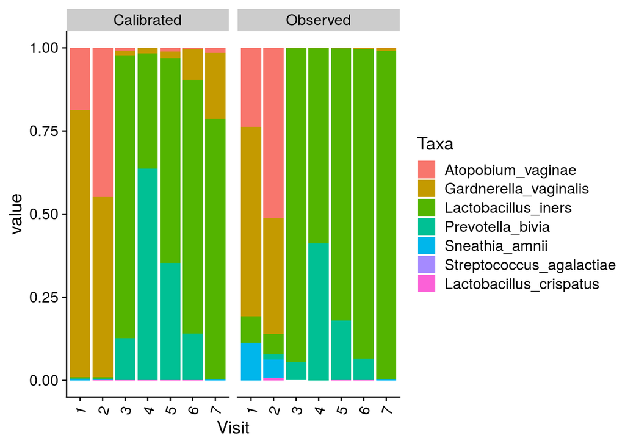

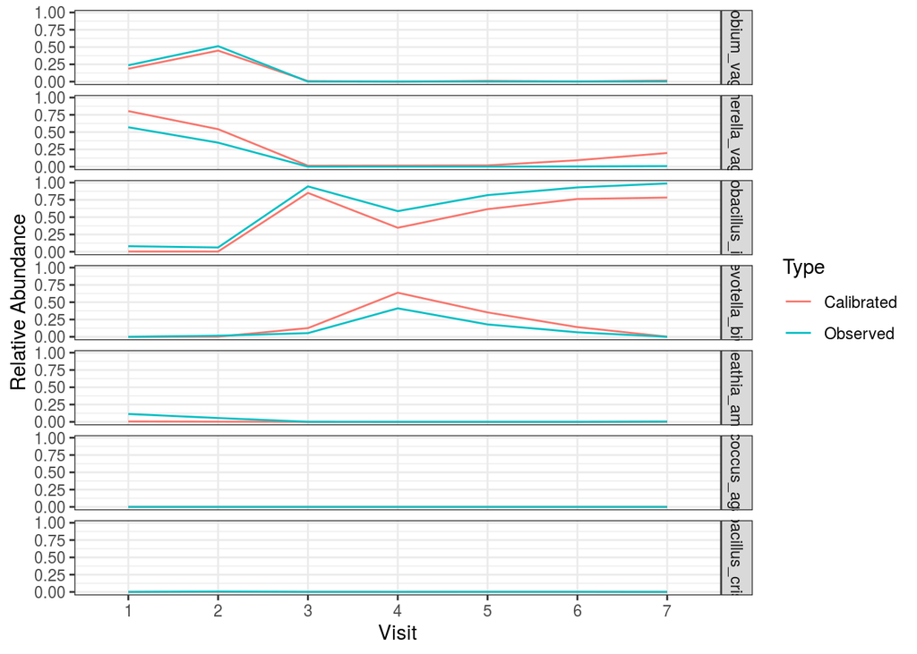

```
##
## [[3]]
##                                 [,1]         [,2]      [,3]      [,4]
## Atopobium_vaginae          2.1662250  0.001057703 0.0000000       Inf
## Gardnerella_vaginalis      0.6086968  0.001563561 1.7180144 0.9393608
## Lactobacillus_iners        0.7778990 15.229377777 0.6214357 1.3946841
## Prevotella_bivia         716.2347024  3.338778308 7.7398304 0.4340421
## Sneathia_amnii             0.4885084  0.009807790 0.0000000       NaN
## Streptococcus_agalactiae         NaN          NaN       NaN       NaN
## Lactobacillus_crispatus  100.5241688  0.080914270 0.8590072 1.8787215
##                               [,5]        [,6]
## Atopobium_vaginae        0.2327762 5.721678626
## Gardnerella_vaginalis    4.4227477 2.194756297
## Lactobacillus_iners      1.1359976 1.061206600
## Prevotella_bivia         0.3639981 0.006080101
## Sneathia_amnii                 NaN         Inf
## Streptococcus_agalactiae       NaN         NaN
## Lactobacillus_crispatus  0.9311048 0.000000000
##
## [[4]]
##                                 [,1]         [,2]      [,3]     [,4]
## Atopobium_vaginae          2.4005932   0.01788523 0.0000000      Inf
## Gardnerella_vaginalis      0.6745529   0.02643903 1.1261153 1.197627
## Lactobacillus_iners        0.8620614 257.52119669 0.4073355 1.778136
## Prevotella_bivia         793.7255358  56.45707906 5.0732642 0.553377
## Sneathia_amnii             0.5413611   0.16584485 0.0000000      NaN
## Streptococcus_agalactiae         NaN          NaN       NaN      NaN
## Lactobacillus_crispatus  111.4000752   1.36822003 0.5630576 2.395254
##                               [,5]        [,6]
## Atopobium_vaginae        0.2537231 5.538274671
## Gardnerella_vaginalis    4.8207384 2.124405092
## Lactobacillus_iners      1.2382229 1.027190448
## Prevotella_bivia         0.3967532 0.005885208
## Sneathia_amnii                 NaN         Inf
## Streptococcus_agalactiae       NaN         NaN
## Lactobacillus_crispatus  1.0148923 0.000000000
```

```r
EP24702_plots <- get_calibrated_plots(as.matrix(EP247202_taxa), mc_fit, meta=MOMS_meta)
EP24702_plots
```

Story from stacked barcharts doesn’t change all that significantly… Most fold changes are the same expcept for Lacto iners… (with a similar story as above)

## Examine subject with highest CoV for Lacto. iners

```r
Cov_of_taxa_iner <- CoV_of_Taxa[grep("iners", CoV_of_Taxa$Group.2),]
which.max(Cov_of_taxa_iner$x)
```

```
## [1] 258
```

```r
Cov_of_taxa_iner[258,]
```

```
##         Group.1             Group.2        x
## 120732 EP422409 Lactobacillus_iners 2.585139
```

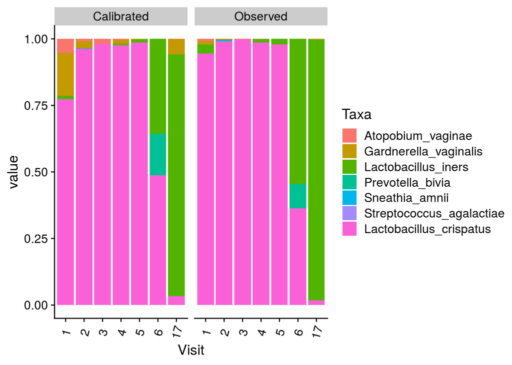

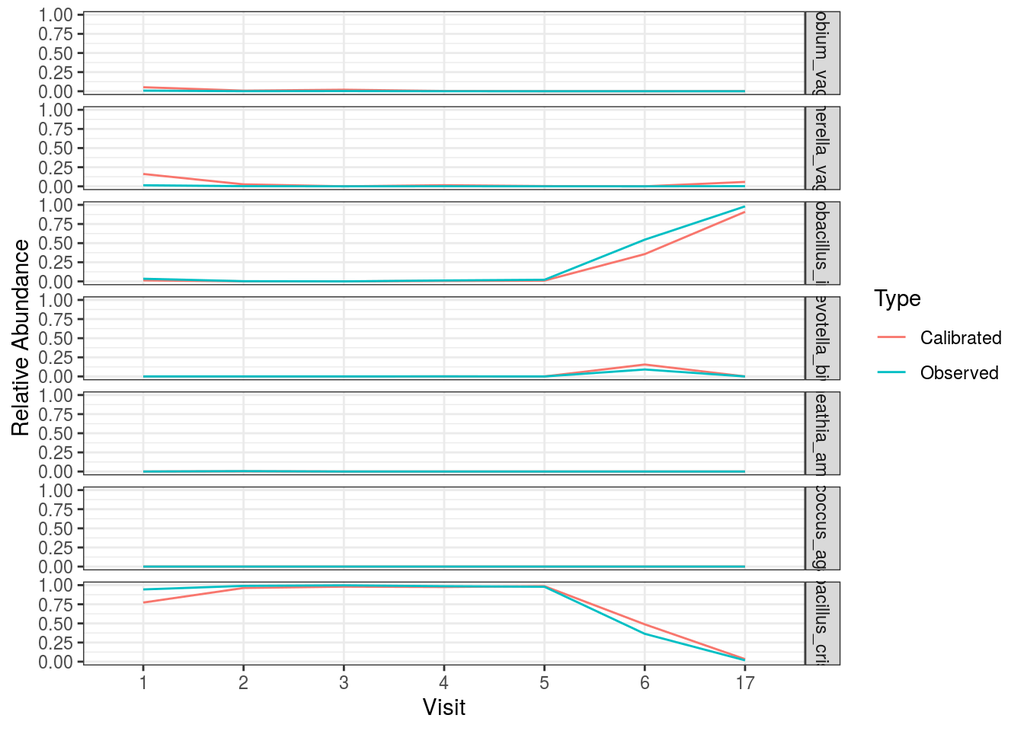

```
##
## [[3]]
##                                  [,1]         [,2]       [,3]        [,4]
## Atopobium_vaginae         0.006674894 18.939023538 2.48640565   0.1795664
## Gardnerella_vaginalis     0.153472743  0.876270840 0.00000000         Inf
## Lactobacillus_iners      28.586191681  0.002492837 0.04578144 106.0564097
## Prevotella_bivia                  NaN          NaN        NaN         Inf
## Sneathia_amnii                    NaN          Inf 0.00000000         NaN
## Streptococcus_agalactiae          NaN          NaN        NaN         NaN
## Lactobacillus_crispatus   0.018185635 57.683761348 1.00725460   0.9885824
##                               [,5]       [,6]
## Atopobium_vaginae        0.0000000        NaN
## Gardnerella_vaginalis    0.2175977  0.0000000
## Lactobacillus_iners      1.7718671 25.9349282
## Prevotella_bivia         0.0000000        Inf
## Sneathia_amnii                 NaN        NaN
## Streptococcus_agalactiae       NaN        NaN
## Lactobacillus_crispatus  0.9926617  0.3715326
##
## [[4]]
##                                 [,1]         [,2]      [,3]        [,4]
## Atopobium_vaginae         0.01549816  9.692597662 2.5123748   0.1807694
## Gardnerella_vaginalis     0.35634192  0.448457159 0.0000000         Inf
## Lactobacillus_iners      66.37307837  0.001275782 0.0462596 106.7669201
## Prevotella_bivia                 NaN          NaN       NaN         Inf
## Sneathia_amnii                   NaN          Inf 0.0000000         NaN
## Streptococcus_agalactiae         NaN          NaN       NaN         NaN
## Lactobacillus_crispatus   0.04222446 29.521347245 1.0177748   0.9952053
##                               [,5]       [,6]
## Atopobium_vaginae        0.0000000        NaN
## Gardnerella_vaginalis    0.2216876  0.0000000
## Lactobacillus_iners      1.8051705 34.4940326
## Prevotella_bivia         0.0000000        Inf
## Sneathia_amnii                 NaN        NaN
## Streptococcus_agalactiae       NaN        NaN
## Lactobacillus_crispatus  1.0113194  0.4941466
```

```r
EP422409_taxa <- MOMS_PI_table[which(MOMS_meta$host_subject_id=="EP422409"),]
EP422409_plot <- get_calibrated_plots(as.matrix(EP422409_taxa), mc_fit, meta=MOMS_meta)
EP422409_plot
```

Interesting the samples are almost all dominated by crispatus which doesn’t change with observed or calibrated values. We some significant changes in fold change values but nothing as extreme as above.